# Ballpark Factor Analysis: Comparing Players

# Research Question

# Narrative Text

**One significant technical challenge**: A major challenge I faced during this project was cleaning and organizing disparate data sources. The player performance data was spread across multiple CSV files, and some datasets lacked critical variables like OPS and Hard-Hit Percentage. I overcame this by carefully merging and transforming the data in R, ensuring consistency and accuracy for the analysis.

# Data Source

**Primary Data Source**: MLB Player Statistics (aggregated from Baseball Savant and team sites)

**Who collected it**: Major League Baseball (MLB) and third-party data providers

**When and why**: Originally collected to track player and team performance metrics during games

```r
library(dplyr)
library(lubridate)
```

```r
library(ggplot2)
library(tidyverse)
library(readr)
library(stringr)

# The data file is in my download folder, so I clarify where the data is located
getwd()
```

```
## [1] "/Users/jjwee/Downloads/Jason's Download/Packages"
```

```r
setwd("/Users/jjwee/Downloads/")

# Load home and away data
seager_home <- read.csv("/Users/jjwee/Downloads/savant_data (3).csv")
seager_away <- read.csv("/Users/jjwee/Downloads/savant_data (4).csv")
arenado_home <- read.csv("/Users/jjwee/Downloads/savant_data (5).csv")
arenado_away <- read.csv("/Users/jjwee/Downloads/savant_data (6).csv")
seager_home_fastball <- read.csv("/Users/jjwee/Downloads/savant_data (7).csv")
seager_home_others <- read.csv("/Users/jjwee/Downloads/savant_data (8).csv")
seager_away_fastball <- read.csv("/Users/jjwee/Downloads/savant_data (9).csv")
seager_away_others <- read.csv("/Users/jjwee/Downloads/savant_data (10).csv")
arenado_home_fastball <- read.csv("/Users/jjwee/Downloads/savant_data (11).csv")
arenado_home_others <- read.csv("/Users/jjwee/Downloads/savant_data (12).csv")
arenado_away_fastball <- read.csv("/Users/jjwee/Downloads/savant_data (13).csv")
arenado_away_others <- read.csv("/Users/jjwee/Downloads/savant_data (14).csv")
```

This code loads the necessary libraries and sets the working directory to the location where the data files are stored. It then reads in multiple CSV files containing baseball performance data for Kyle Seager and Nolan Arenado, with separate datasets for home and away games as well as pitch types (fastballs and others). These datasets will be used for further analysis and comparison of the players’ performance across different game locations and pitch types.

```r
str(seager_home)
```

```
## 'data.frame':    1 obs. of  70 variables:
##  $ pitches                  : int 11823
##  $ player_id                : int 572122
##  $ player_name              : chr "Seager, Kyle"
##  $ total_pitches            : int 23992
##  $ pitch_percent            : num 49.3
##  $ ba                       : num 0.237
##  $ iso                      : num 0.164
##  $ babip                    : num 0.264
##  $ slg                      : num 0.401
##  $ woba                     : num 0.314
##  $ xwoba                    : num 0.336
##  $ xba                      : num 0.25
##  $ hits                     : int 632
##  $ abs                      : int 2664
```

[output cut: 56 more lines]

```r
str(seager_away)
```

```
## 'data.frame':    1 obs. of  70 variables:
##  $ pitches                  : int 12169
##  $ player_id                : int 572122
##  $ player_name              : chr "Seager, Kyle"
##  $ total_pitches            : int 23992
##  $ pitch_percent            : num 50.7
##  $ ba                       : num 0.263
##  $ iso                      : num 0.216
##  $ babip                    : num 0.279
##  $ slg                      : num 0.48
##  $ woba                     : num 0.342
##  $ xwoba                    : num 0.349
##  $ xba                      : num 0.268
##  $ hits                     : int 763
##  $ abs                      : int 2897
```

[output cut: 56 more lines]

```r
str(arenado_home)
```

```
## 'data.frame':    1 obs. of  70 variables:
##  $ pitches                  : int 8287
##  $ player_id                : int 571448
##  $ player_name              : chr "Arenado, Nolan"
##  $ total_pitches            : int 16696
##  $ pitch_percent            : num 49.6
##  $ ba                       : num 0.322
##  $ iso                      : num 0.287
##  $ babip                    : num 0.322
##  $ slg                      : num 0.609
##  $ woba                     : num 0.409
##  $ xwoba                    : num 0.368
##  $ xba                      : num 0.285
##  $ hits                     : int 669
##  $ abs                      : int 2080
```

[output cut: 56 more lines]

```r
str(arenado_away)
```

```
## 'data.frame':    1 obs. of  70 variables:
##  $ pitches                  : int 8409
##  $ player_id                : int 571448
##  $ player_name              : chr "Arenado, Nolan"
##  $ total_pitches            : int 16696
##  $ pitch_percent            : num 50.4
##  $ ba                       : num 0.263
##  $ iso                      : num 0.208
##  $ babip                    : num 0.274
##  $ slg                      : num 0.471
##  $ woba                     : num 0.334
##  $ xwoba                    : num 0.323
##  $ xba                      : num 0.248
##  $ hits                     : int 537
##  $ abs                      : int 2038
```

[output cut: 56 more lines]

```r
colnames(seager_home)
```

```
##  [1] "pitches"                   "player_id"
##  [3] "player_name"               "total_pitches"
##  [5] "pitch_percent"             "ba"
##  [7] "iso"                       "babip"
##  [9] "slg"                       "woba"
## [11] "xwoba"                     "xba"
## [13] "hits"                      "abs"
## [15] "launch_speed"              "launch_angle"
## [17] "spin_rate"                 "velocity"
## [19] "effective_speed"           "whiffs"
## [21] "swings"                    "takes"
## [23] "eff_min_vel"               "release_extension"
## [25] "pos3_int_start_distance"   "pos4_int_start_distance"
## [27] "pos5_int_start_distance"   "pos6_int_start_distance"
## [29] "pos7_int_start_distance"   "pos8_int_start_distance"
```

[output cut: 20 more lines]

```r
seager_home %>%
  select(hrs, hits, ba, obp, slg, xwoba, xba, xobp, xslg, iso, babip, bb)
```

```
##   hrs hits    ba   obp   slg xwoba  xba  xobp  xslg   iso babip  bb
## 1  95  632 0.237 0.318 0.401 0.336 0.25 0.335 0.441 0.164 0.264 291
```

The colnames(seager_home) function displays the names of all columns in the seager_home data frame.

The seager_home %>% select(…) part selects specific columns (hrs, hits, ba, obp, etc.) from the seager_home data frame to display or work with, making it easier to focus on key metrics like home runs, batting average, and on-base percentage.

```r
colnames(seager_away)
```

```
##  [1] "pitches"                   "player_id"
##  [3] "player_name"               "total_pitches"
##  [5] "pitch_percent"             "ba"
##  [7] "iso"                       "babip"
##  [9] "slg"                       "woba"
## [11] "xwoba"                     "xba"
## [13] "hits"                      "abs"
## [15] "launch_speed"              "launch_angle"
## [17] "spin_rate"                 "velocity"
## [19] "effective_speed"           "whiffs"
## [21] "swings"                    "takes"
## [23] "eff_min_vel"               "release_extension"
## [25] "pos3_int_start_distance"   "pos4_int_start_distance"
## [27] "pos5_int_start_distance"   "pos6_int_start_distance"
## [29] "pos7_int_start_distance"   "pos8_int_start_distance"
```

[output cut: 20 more lines]

```r
seager_away %>%
  select(hrs, hits, ba, obp, slg, xwoba, xba, xobp, xslg, iso, babip, bb)
```

```
##   hrs hits    ba   obp  slg xwoba   xba  xobp  xslg   iso babip  bb
## 1 147  763 0.263 0.321 0.48 0.349 0.268 0.326 0.491 0.216 0.279 228
```

The colnames(seager_away) function displays the names of all columns in the seager_away data frame.

The seager_away %>% select(…) part selects specific columns (hrs, hits, ba, obp, etc.) from the seager_away data frame, allowing you to focus on key performance metrics such as home runs, batting average, and on-base percentage for Seager’s away games.

```r
colnames(arenado_home)
```

```
##  [1] "pitches"                   "player_id"
##  [3] "player_name"               "total_pitches"
##  [5] "pitch_percent"             "ba"
##  [7] "iso"                       "babip"
##  [9] "slg"                       "woba"
## [11] "xwoba"                     "xba"
## [13] "hits"                      "abs"
## [15] "launch_speed"              "launch_angle"
## [17] "spin_rate"                 "velocity"
## [19] "effective_speed"           "whiffs"
## [21] "swings"                    "takes"
## [23] "eff_min_vel"               "release_extension"
## [25] "pos3_int_start_distance"   "pos4_int_start_distance"
## [27] "pos5_int_start_distance"   "pos6_int_start_distance"
## [29] "pos7_int_start_distance"   "pos8_int_start_distance"
```

[output cut: 20 more lines]

```r
arenado_home %>%
  select(hrs, hits, ba, obp, slg, xwoba, xba, xobp, xslg, iso, babip, bb)
```

```
##   hrs hits    ba   obp   slg xwoba   xba  xobp  xslg   iso babip  bb
## 1 136  669 0.322 0.372 0.609 0.368 0.285 0.345 0.527 0.287 0.322 169
```

The colnames(arenado_home) function displays the names of all columns in the arenado_home data frame.

The arenado_home %>% select(…) part selects specific columns (hrs, hits, ba, obp, etc.) from the arenado_home data frame, focusing on important performance metrics like home runs, batting average, and on-base percentage for Arenado’s home games.

```r
colnames(arenado_away)
```

```
##  [1] "pitches"                   "player_id"
##  [3] "player_name"               "total_pitches"
##  [5] "pitch_percent"             "ba"
##  [7] "iso"                       "babip"
##  [9] "slg"                       "woba"
## [11] "xwoba"                     "xba"
## [13] "hits"                      "abs"
## [15] "launch_speed"              "launch_angle"
## [17] "spin_rate"                 "velocity"
## [19] "effective_speed"           "whiffs"
## [21] "swings"                    "takes"
## [23] "eff_min_vel"               "release_extension"
## [25] "pos3_int_start_distance"   "pos4_int_start_distance"
## [27] "pos5_int_start_distance"   "pos6_int_start_distance"
## [29] "pos7_int_start_distance"   "pos8_int_start_distance"
```

[output cut: 20 more lines]

```r
arenado_away %>%
  select(hrs, hits, ba, obp, slg, xwoba, xba, xobp, xslg, iso, babip, bb)
```

```
##   hrs hits    ba   obp   slg xwoba   xba  xobp  xslg   iso babip  bb
## 1  99  537 0.263 0.317 0.471 0.323 0.248 0.311 0.441 0.208 0.274 160
```

The colnames(arenado_away) function displays the names of all columns in the arenado_away data frame.

The arenado_away %>% select(…) part selects specific columns (hrs, hits, ba, obp, etc.) from the arenado_away data frame, focusing on key performance metrics like home runs, batting average, and on-base percentage for Arenado’s away games.

```r
# Add player and location columns to each dataset
seager_home <- seager_home %>%
  mutate(player = "Seager", location = "Home")
seager_away <- seager_away %>%
  mutate(player = "Seager", location = "Away")
arenado_home <- arenado_home %>%
  mutate(player = "Arenado", location = "Home")
arenado_away <- arenado_away %>%
  mutate(player = "Arenado", location = "Away")

# Combine all datasets into one
combined_data <- bind_rows(seager_home, seager_away, arenado_home, arenado_away)
```

This code processes and combines baseball performance data for Kyle Seager and Nolan Arenado, comparing their home and away game performances. It first adds two columns—player (Seager or Arenado) and location (Home or Away)—to each dataset. Then, it merges all four datasets (Seager’s and Arenado’s home and away data) into one unified dataset using bind_rows(). The resulting combined data is ready for further analysis or visualization.

```r
# Summarise key metrics
summary_data <- combined_data %>%
  group_by(player, location) %>%
  summarise(
    hrs = sum(hrs, na.rm = TRUE),
    hits = sum(hits, na.rm = TRUE),
    ba = mean(ba, na.rm = TRUE),
    obp = mean(obp, na.rm = TRUE),
    slg = mean(slg, na.rm = TRUE),
    xwoba = mean(xwoba, na.rm = TRUE),
    iso = mean(iso, na.rm = TRUE),
    babip = mean(babip, na.rm = TRUE),
    bb = sum(bb, na.rm = TRUE)
  )
```

This code summarizes key performance metrics for Kyle Seager and Nolan Arenado, grouped by player and location (home or away). It calculates the total home runs and walks, along with the average values for batting average, on-base percentage, slugging percentage, expected wOBA, isolated power, and batting average on balls in play. Missing values are excluded using na.rm = TRUE.

```r
# Example: Adding ballpark factors manually
ballpark_factors <- data.frame(
  location = c("Home", "Away"),
  park_factor = c(1.14, 0.94) # Adjust based on your actual data
)

# Join ballpark factors with summarised data
summary_data <- summary_data %>%
  left_join(ballpark_factors, by = "location")
```

This code adds ballpark factors to the summarized performance data by joining a manually created dataset (ballpark_factors) with the existing summary_data. The ballpark factors dataset includes location-specific adjustments (Home or Away), with park factors applied to each location. The left_join() function is used to merge these factors with the summary data based on the location column.

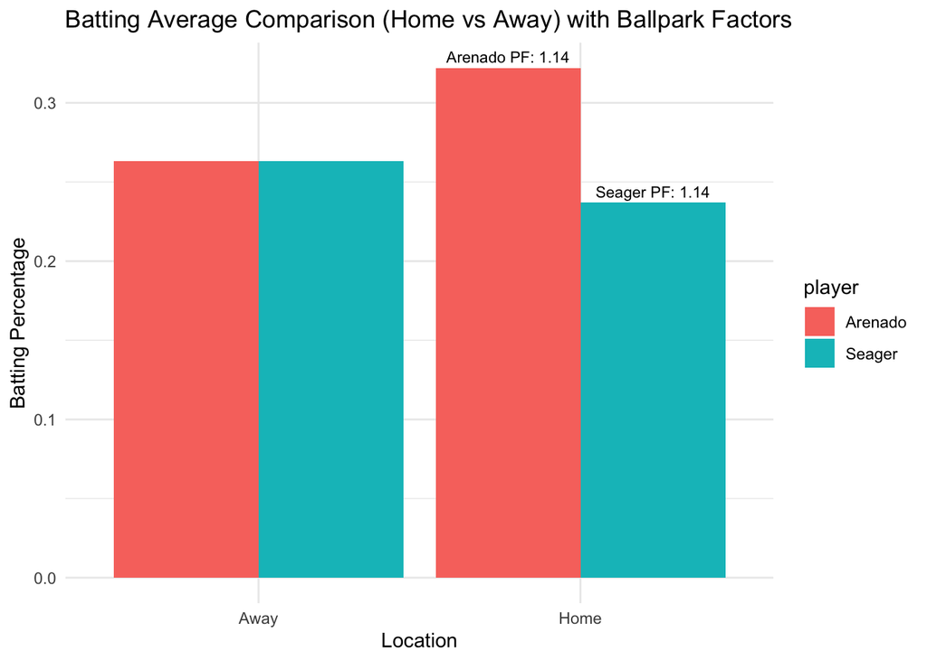

```r
# Create a bar plot comparing Batting Average for Seager and Arenado, with ballpark factors displayed for Home location
ggplot(summary_data, aes(x = location, y = ba, fill = player)) +
  geom_bar(stat = "identity", position = "dodge") + # Bar plot with side-by-side comparison
  # Add park factors only for Home, specific to each player
  geom_text(
    aes(label = ifelse(location == "Home", paste(player, "PF:", park_factor), "")),
    position = position_dodge(width = 0.9),
    vjust = -0.5,
    size = 3 # Adding text labels for park factors
  ) +
  labs(
    title = "Batting Average Comparison (Home vs Away) with Ballpark Factors",
    x = "Location",
    y = "Batting Percentage"
  ) +
  theme_minimal() # Clean, minimal theme
```

By comparing home and away batting averages, Arenado’s home batting average is significantly better than Seager’s, largely due to the favorable park factor of Coors Field. However, their away batting averages are nearly identical. This suggests that Coors Field positively impacts Arenado’s batting stats. In contrast, Seager performs better on the road, with a higher batting average in away games compared to his home games.

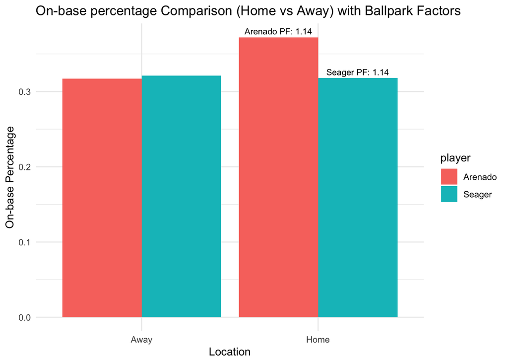

```r
ggplot(summary_data, aes(x = location, y = obp, fill = player)) +
  geom_bar(stat = "identity", position = "dodge") +
  geom_text(
    aes(label = ifelse(location == "Home", paste(player, "PF:", park_factor), "")),
    position = position_dodge(width = 0.9),
    vjust = -0.5,
    size = 3
  ) +
  labs(
    title = "On-base percentage Comparison (Home vs Away) with Ballpark Factors",
    x = "Location",
    y = "On-base Percentage"
  ) +
  theme_minimal()
```

On-base percentage and batting average both indicate that Arenado performs slightly better at home compared to Seager. However, Seager has a marginally higher on-base percentage than Arenado in away games.

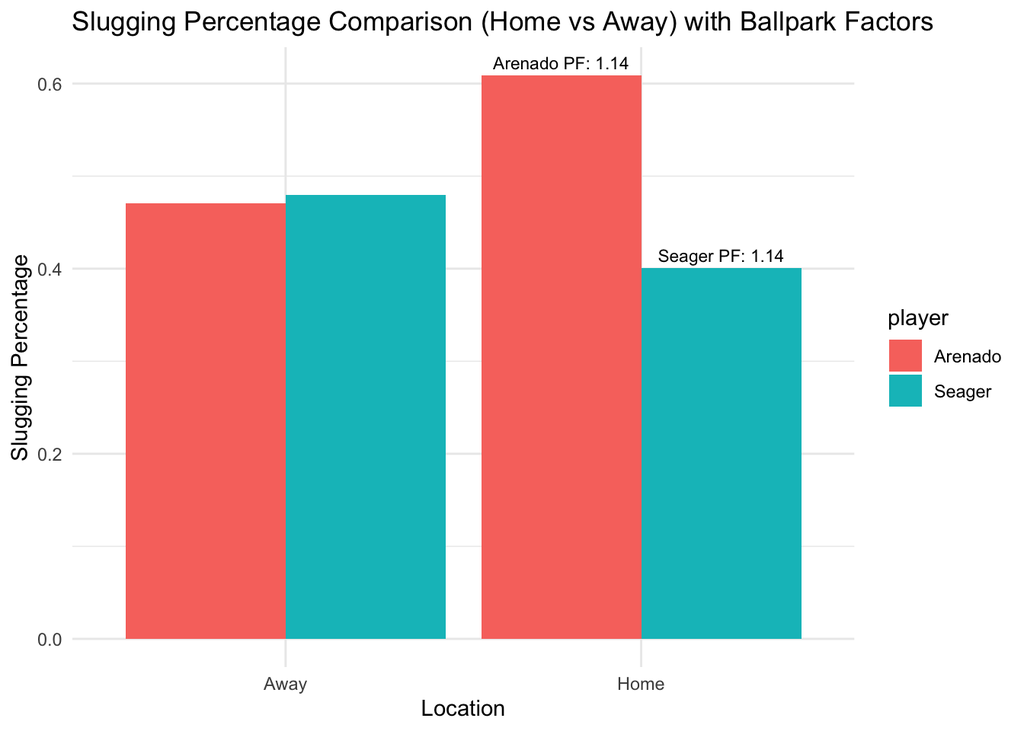

```r
ggplot(summary_data, aes(x = location, y = slg, fill = player)) +
  geom_bar(stat = "identity", position = "dodge") +
  # Add park factors only for Home, specific to each player
  geom_text(
    aes(label = ifelse(location == "Home", paste(player, "PF:", park_factor), "")),
    position = position_dodge(width = 0.9),
    vjust = -0.5,
    size = 3
  ) +
  labs(
    title = "Slugging Percentage Comparison (Home vs Away) with Ballpark Factors",
    x = "Location",
    y = "Slugging Percentage"
  ) +
  theme_minimal()
```

Slugging percentage is a crucial stat for comparing these two power hitters, both of whom have over 200 career home runs. Arenado’s slugging percentage is much higher at home, largely due to favorable park factors. However, Seager has a slightly better slugging percentage than Arenado in away games.

```r
# Reshape the summary_data into long format
long_summary_data <- summary_data %>%
  pivot_longer(cols = c(hrs, hits, xwoba, iso, babip, bb),
               names_to = "metric",
               values_to = "value")
```

This code reshapes the summary_data dataset from wide to long format using the pivot_longer() function. It consolidates multiple performance metrics (hrs, hits, xwoba, iso, babip, bb) into two columns: metric (indicating the metric name) and value (containing the corresponding values). This transformation is useful for comparisons, visualizations, or further analysis.

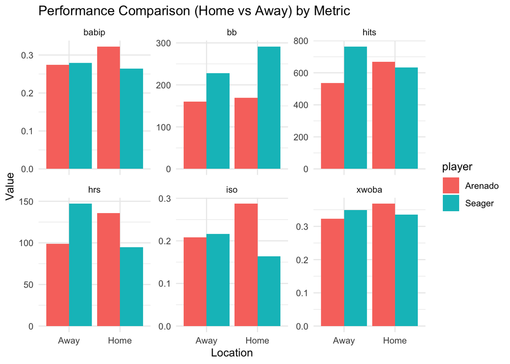

```r
ggplot(long_summary_data, aes(x = location, y = value, fill = player)) +
  geom_bar(stat = "identity", position = "dodge") +
  facet_wrap(~ metric, scales = "free_y") +  # Facet by metric
  labs(
    title = "Performance Comparison (Home vs Away) by Metric",
    x = "Location",
    y = "Value"
  ) +
  theme_minimal()
```

This visualization compares advanced metrics (BABIP, BB, HITS, HRs, ISO, and xwOBA) for Nolan Arenado and Kyle Seager in home and away games. Arenado’s home stats are generally higher than Seager’s, likely influenced by Coors Field’s hitter-friendly park factor. However, Seager’s walk stat (BB) is significantly better than Arenado’s in both home and away games. Conversely, Seager outperforms Arenado in away games across most metrics. This comparison underscores the significant role of park factors and location in influencing player performance.

```r
# Add player and location to each dataset
seager_home_fastball <- seager_home_fastball %>%
  mutate(player = "Seager", location = "Home", pitch_type = "Fastball")
seager_home_others <- seager_home_others %>%
  mutate(player = "Seager", location = "Home", pitch_type = "Other")
seager_away_fastball <- seager_away_fastball %>%
  mutate(player = "Seager", location = "Away", pitch_type = "Fastball")
seager_away_others <- seager_away_others %>%
  mutate(player = "Seager", location = "Away", pitch_type = "Other")
arenado_home_fastball <- arenado_home_fastball %>%
  mutate(player = "Arenado", location = "Home", pitch_type = "Fastball")
arenado_home_others <- arenado_home_others %>%
  mutate(player = "Arenado", location = "Home", pitch_type = "Other")
arenado_away_fastball <- arenado_away_fastball %>%
  mutate(player = "Arenado", location = "Away", pitch_type = "Fastball")
arenado_away_others <- arenado_away_others %>%
  mutate(player = "Arenado", location = "Away", pitch_type = "Other")
```

This code adds three new columns (player, location, and pitch_type) to each dataset for Kyle Seager and Nolan Arenado, categorized by home/away location and pitch type (Fastball or Other). The mutate() function is used to label each dataset accordingly, preparing the data for more granular analysis based on player, location, and pitch type.

```r
# Combine all the datasets into one
combined_data2 <- bind_rows(
  seager_home_fastball, seager_home_others, seager_away_fastball, seager_away_others,
  arenado_home_fastball, arenado_home_others, arenado_away_fastball, arenado_away_others
)
```

This code combines all the individual datasets for Kyle Seager and Nolan Arenado, categorized by home/away location and pitch type, into a single unified dataset using bind_rows(). This consolidated dataset is now ready for further analysis or comparison across different player, location, and pitch type categories.

```r
# Summarise performance by player, location, and pitch type
summary_data2 <- combined_data2 %>%
  group_by(player, location, pitch_type) %>%
  summarise(
    avg_ba = mean(ba, na.rm = TRUE),
    avg_obp = mean(obp, na.rm = TRUE),
    avg_slg = mean(slg, na.rm = TRUE),
    total_hits = sum(hits, na.rm = TRUE),
    total_hrs = sum(hrs, na.rm = TRUE)
  )
```

This code summarizes the performance of Kyle Seager and Nolan Arenado by player, location, and pitch type. It calculates the average batting average (avg_ba), on-base percentage (avg_obp), and slugging percentage (avg_slg), along with the total number of hits (total_hits) and home runs (total_hrs). Missing values are excluded using na.rm = TRUE.

```r
colnames(summary_data2)
```

```
## [1] "player"     "location"   "pitch_type" "avg_ba"     "avg_obp"
## [6] "avg_slg"    "total_hits" "total_hrs"
```

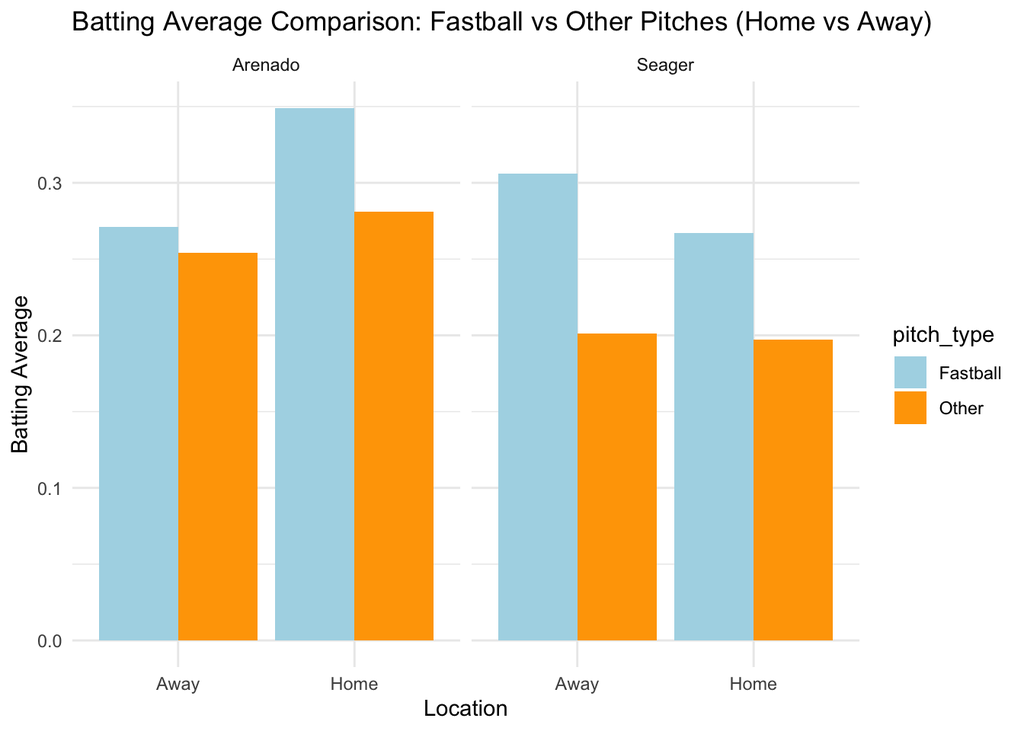

```r
ggplot(summary_data2, aes(x = location, y = avg_ba, fill = pitch_type)) +
  geom_bar(stat = "identity", position = "dodge") +
  facet_wrap(~ player) +  # Facet by player
  labs(
    title = "Batting Average Comparison: Fastball vs Other Pitches (Home vs Away)",
    x = "Location",
    y = "Batting Average"
  ) +
  theme_minimal() +
  scale_fill_manual(values = c("lightblue", "orange"))
```

This visualization compares the batting averages of Nolan Arenado and Kyle Seager, segmented by pitch type (fastballs vs. other pitches) and game location (home vs. away). Arenado shows a significant boost in batting average at home, especially against fastballs, suggesting a strong home-field advantage. In contrast, Seager has a batting average over .300 against fastballs on the road, but his batting average against other pitches, such as breaking balls and changeups, is relatively low, nearly .200 both at home and away. This chart highlights the differing impact of location and pitch type on their batting performance.

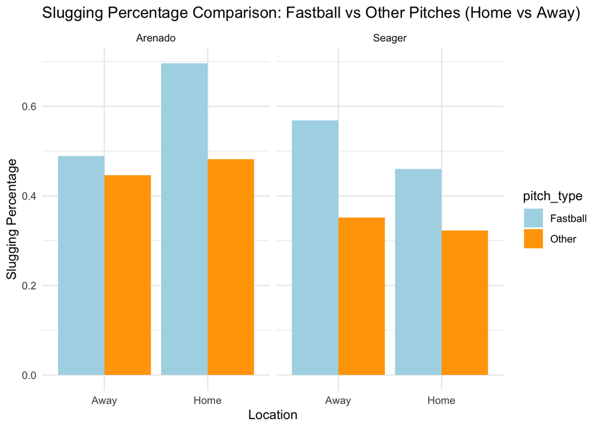

```r
ggplot(summary_data2, aes(x = location, y = avg_slg, fill = pitch_type)) +
  geom_bar(stat = "identity", position = "dodge") +
  facet_wrap(~ player) +  # Facet by player
  labs(
    title = "Slugging Percentage Comparison: Fastball vs Other Pitches (Home vs Away)",
    x = "Location",
    y = "Slugging Percentage"
  ) +
  theme_minimal() +
  scale_fill_manual(values = c("lightblue", "orange"))
```

This visualization compares slugging percentages for Nolan Arenado and Kyle Seager, broken down by pitch type (fastballs vs. other pitches) and location (home vs. away). Arenado demonstrates a notably higher slugging percentage at home, particularly against fastballs, while Seager’s slugging percentage against other pitches, as well as his batting average, shows very poor performance in both home and away games. This analysis highlights the impact of pitch type and location on players’ slugging performance.

```r
# Pivot longer and rename metrics
long_summary_data2 <- summary_data2 %>%
  pivot_longer(cols = c("avg_ba", "avg_obp", "avg_slg", "total_hits", "total_hrs"),
               names_to = "metric",
               values_to = "value") %>%
  mutate(
    metric = recode(
      metric,
      "avg_ba" = "BA",
      "avg_obp" = "OBP",
      "avg_slg" = "SLG",
      "total_hits" = "Total Hits",
      "total_hrs" = "Total Home Runs"
    )
  )
```

This code reshapes the summary_data2 dataset into a longer format using pivot_longer(), converting multiple performance metrics (batting average, on-base percentage, slugging percentage, total hits, and total home runs) into key-value pairs. It also renames the metrics for clarity, changing column names such as “avg_ba” to “BA” and “total_hits” to “Total Hits.” This transformation makes the data more suitable for visualizations or further analysis.

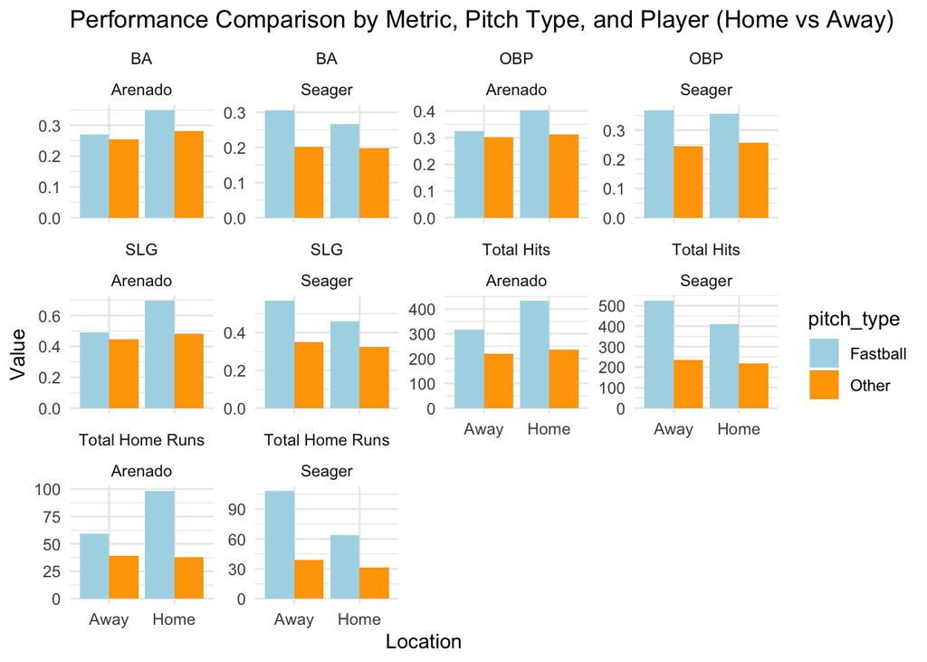

```r
ggplot(long_summary_data2, aes(x = location, y = value, fill = pitch_type)) +
  geom_bar(stat = "identity", position = "dodge") +
  facet_wrap(~ metric + player, scales = "free_y") +  # Facet by metric and player
  labs(
    title = "Performance Comparison by Metric, Pitch Type, and Player (Home vs Away)",
    x = "Location",
    y = "Value"
  ) +
  theme_minimal() +
  scale_fill_manual(values = c("lightblue", "orange"))  # Custom color palette
```

This visualization compares Nolan Arenado’s and Kyle Seager’s hitting metrics (BA, OBP, SLG, Total Hits, and Total Home Runs) by location (home vs. away) and pitch type (Fastball vs. Other). Each player’s metrics are displayed in separate facets for clear comparison. The use of independent y-axes and distinct color coding—light blue for Fastball and orange for Other—effectively highlights the impact of pitch types on performance.

Key Observations Arenado’s Home Performance: 1. Fastball Dominance: Arenado performs exceptionally well on fastballs at home, with notable strengths in Total Hits and Total Home Runs. 2. Consistency on Away Games: His performance on both fastballs and other pitch types remains consistent only in away games, indicating that location has little impact on his success with these pitches outside of Coors Field. 3. Ballpark Effect: Coors Field’s hitter-friendly environment likely enhances Arenado’s performance, especially against fastballs.

Seager’s Away Performance: Away Game Advantage: Seager’s away stats outperform his home stats, particularly in Total Hits and Total Home Runs. This suggests that T-Mobile Park, Seager’s home park, has a pitcher-friendly environment that suppresses his performance, while he thrives in more neutral or hitter-friendly ballparks.

Approach to Pitch Types: 1. Arenado vs. Seager on Non-Fastballs: Arenado shows superior performance against non-fastball pitches both at home and away. suggesting he handles a variety of pitch types more effectively than Seager. 2. Seager’s Fastball Performance: Seager performs similarly to Arenado on fastballs but struggles more against other pitches, indicating less versatility in adapting to pitch variations.